# EDA_311_Data

This document contains an exploratory data analysis of 311 Call Center Data. We perform TimeSeries Analysis of the Data

```r
DataRoot<-"C:/Users/Hackuser1/Hackathon18"
InputFile<-file.path(DataRoot,"311_call_metrics.csv")
data<-read.csv(InputFile)
#Sort Data on the basis of Date
data<-data[order(as.Date(data$month, format="%d/%m/%Y")),]
data$month<-NULL
data$svc_level_answered_w_i_60_sec<-NULL
data$avg_speed_answer_sec<-NULL
data$transferred_calls<-NULL
TimeSeriesData<-ts(data,frequency = 12,start=c(2007,4))
TimeSeriesData
```

```
##         Jan    Feb    Mar    Apr    May    Jun    Jul    Aug    Sep    Oct
## 2007                       71042  70038  73047  74445  73027  77644  74064
## 2008  89074  83668  95264  98471  92950 104600  96923  94395  94203 102033
## 2009 110136 100580 121394 113750 113133 126056 121604 121104 116029 117349
## 2010 125825 120020 131558 120220 114922 122768 118191 127378 136980 138571
## 2011 166171 165053 184228 181294 170315 181815 181669 191730 185664 196064
## 2012 214265 192744 185076 164937 178612 168948 186327 187189 204547 224528
## 2013 220417 249735 240583 218179 225413 245370 238607 232628 252511 275526
## 2014 277695 300802 287992 269631 280100 311183 272756 277562 242789 248027
## 2015 215748 209998 175737 173047 111137  78059  73083  72182  68355  75324
## 2016  75454  87389 282590  81765 205797  80919  74029  76264 250749  88607
## 2017  79410  73427  76847  75870  76892  75949  68468  72996  91892 160996
##         Nov    Dec
## 2007  80836  84685
## 2008 107497 103566
## 2009 124333 122734
## 2010 148285 156245
## 2011 213989 218046
## 2012 217776 228119
## 2013 287364 295455
## 2014 247503 231879
## 2015  75324  77887
## 2016  73473 141639
## 2017 293598  72053
```

Lets analyze the Call Volume

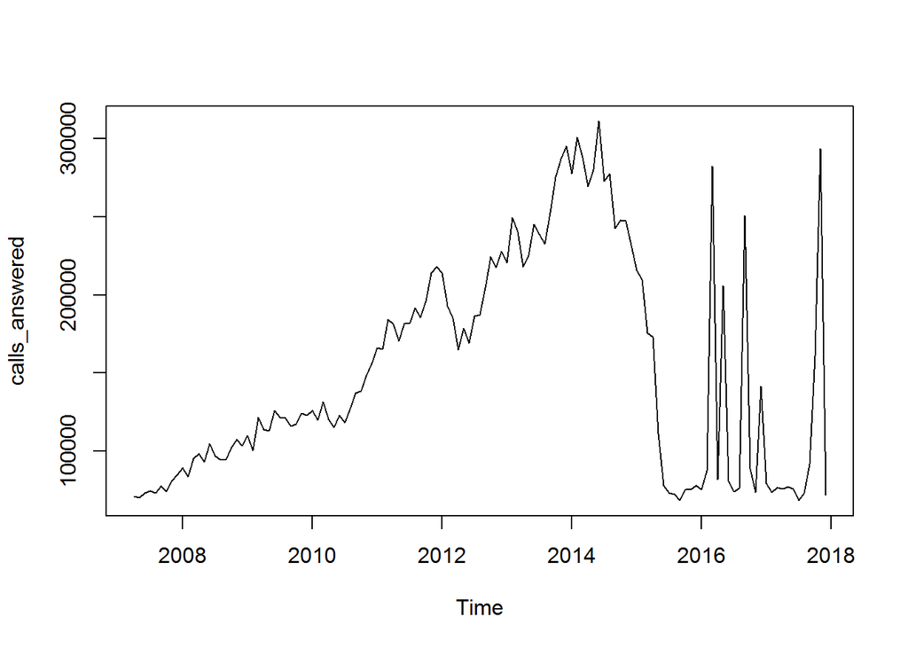

```r
plot.ts(TimeSeriesData)
```

To estimate the trend, seasonal and irregular components of this time series,lets decompose the timeseries

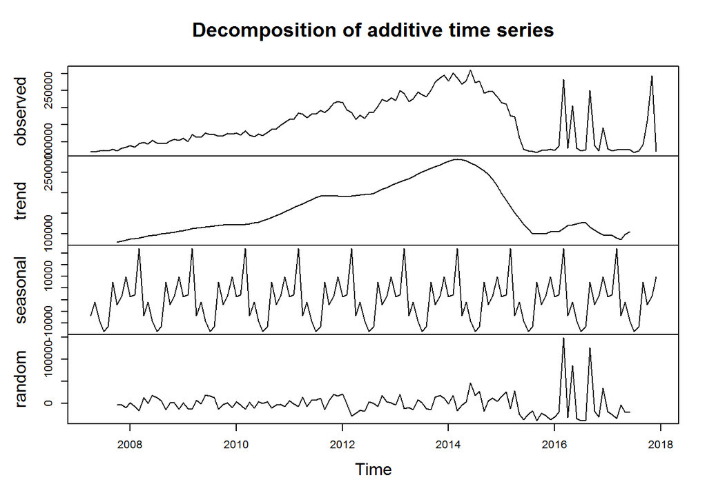

```r
timeseriescomponents<-decompose(TimeSeriesData)
plot(timeseriescomponents)
```

We can see that the timeseries has a seasonal component.

Holt-Winters Exponential Smoothing: If we have a time series that can be described using an additive model with increasing or decreasing trend and seasonality, we can use Holt-Winters exponential smoothing to make short-term forecasts.

Holt-Winters exponential smoothing estimates the level, slope and seasonal component at the current time point. Smoothing is controlled by three parameters: alpha, beta, and gamma, for the estimates of the level, slope b of the trend component, and the seasonal component, respectively, at the current time point. The parameters alpha, beta and gamma all have values between 0 and 1, and values that are close to 0 mean that relatively little weight is placed on the most recent observations when making forecasts of future values.

```r
timeseriesforecasts <- HoltWinters(TimeSeriesData)
timeseriesforecasts
```

```
## Holt-Winters exponential smoothing with trend and additive seasonal component.
##
## Call:
## HoltWinters(x = TimeSeriesData)
##
## Smoothing parameters:
##  alpha: 0.4408778
##  beta : 0
##  gamma: 0
##
## Coefficients:
##            [,1]
## a   144390.7072
## b     1910.8698
## s1    2674.7153
## s2   -4558.2014
## s3    5457.5069
## s4    6809.1736
## s5    -988.0764
## s6    8764.3403
## s7    -576.9514
## s8   -4687.2014
## s9   -6672.6181
## s10  -5717.0764
## s11  -1042.6181
## s12    537.0069
```

We can plot the original time series as a black line, with the forecasted values as a red line on top of that:

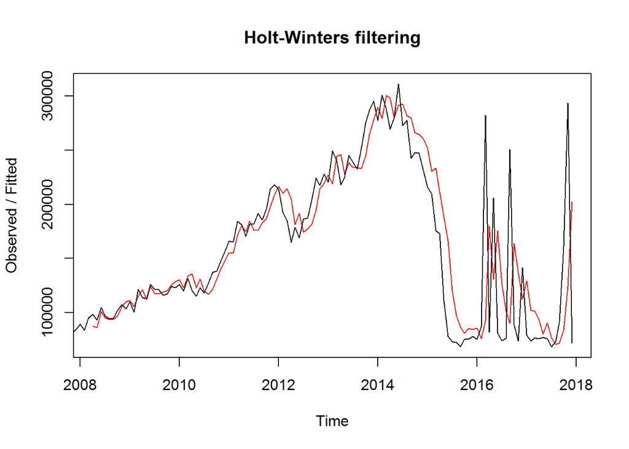

```r
plot(timeseriesforecasts)
```

To make forecasts for future times not included in the original time series, we use the “forecast.HoltWinters()” function in the “forecast” package. For instance, inorder to forecast for the next 3 years, we provide h=36(months)

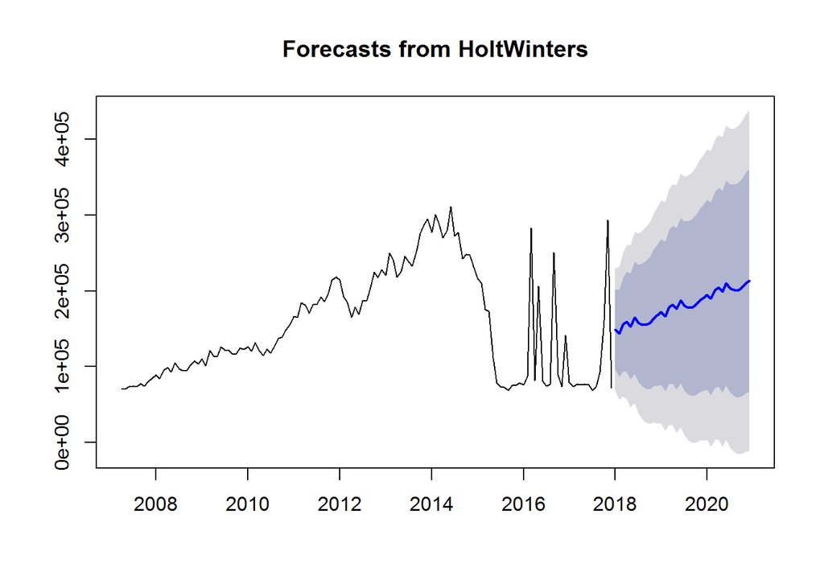

```r
library(forecast)
timeseriesforecasts2 <- forecast:::forecast.HoltWinters(timeseriesforecasts, h=36)
plot(timeseriesforecasts2)
```

The forecasts are shown as a blue line, and the dark grey and grey shaded areas show 80% and 95% prediction intervals, respectively.

We can investigate whether the predictive model can be improved upon by checking whether the in-sample forecast errors show non-zero autocorrelations at lags 1-20, by making a correlogram and carrying out the Ljung-Box test:

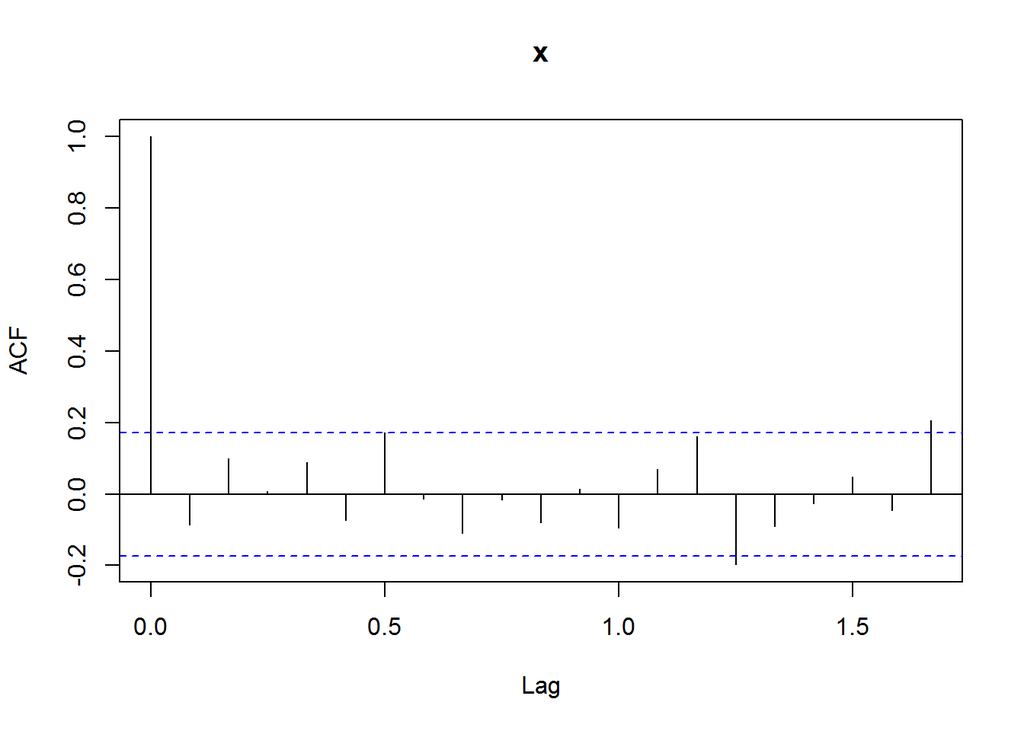

```r
acf(timeseriesforecasts2$residuals, lag.max=20,na.action = na.pass)
```

```r
Box.test(timeseriesforecasts2$residuals, lag=20, type="Ljung-Box")
```

```
##
##  Box-Ljung test
##
## data:  timeseriesforecasts2$residuals
## X-squared = 28.551, df = 20, p-value = 0.09699
```

ARIMA:

Exponential smoothing methods are useful for making forecasts, and make no assumptions about the correlations between successive values of the time series. However, if we want to make prediction intervals for forecasts made using exponential smoothing methods, the prediction intervals require that the forecast errors are uncorrelated and are normally distributed with mean zero and constant variance.

While exponential smoothing methods do not make any assumptions about correlations between successive values of the time series, in some cases we can make a better predictive model by taking correlations in the data into account. Autoregressive Integrated Moving Average (ARIMA) models include an explicit statistical model for the irregular component of a time series, that allows for non-zero autocorrelations in the irregular component.

Differencing a Time Series:

ARIMA models are defined for stationary time series. Therefore, if we start off with a non-stationary time series, we will first need to ‘difference’ the time series until we obtain a stationary time series. If we have to difference the time series d times to obtain a stationary series, then we have an ARIMA(p,d,q) model, where d is the order of differencing used.

We can difference a time series using the “diff()” function in R. For example,

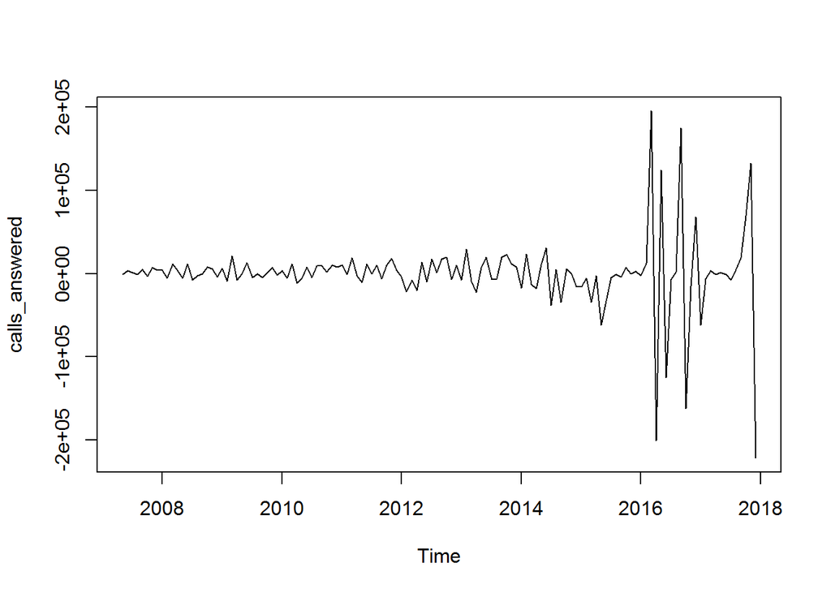

```r
TimeSeriesDataDiff <- diff(TimeSeriesData, differences=1)
plot.ts(TimeSeriesDataDiff)
```

The resulting time series of first differences (above) does not appear to be stationary in mean. Therefore, we can difference the time series twice, to see if that gives us a stationary time series:

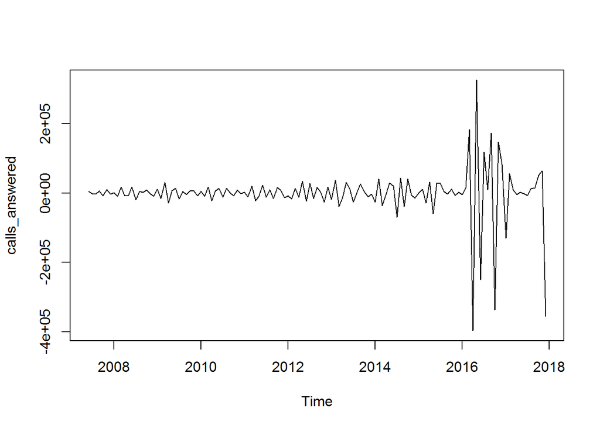

```r
TimeSeriesDataDiff2 <- diff(TimeSeriesData, differences=2)
plot.ts(TimeSeriesDataDiff2)
```

The next step is to select the appropriate ARIMA model, which means finding the values of most appropriate values of p and q for an ARIMA(p,d,q) model. To do this, we usually need to examine the correlogram and partial correlogram of the stationary time series.

To plot the correlogram, we type:

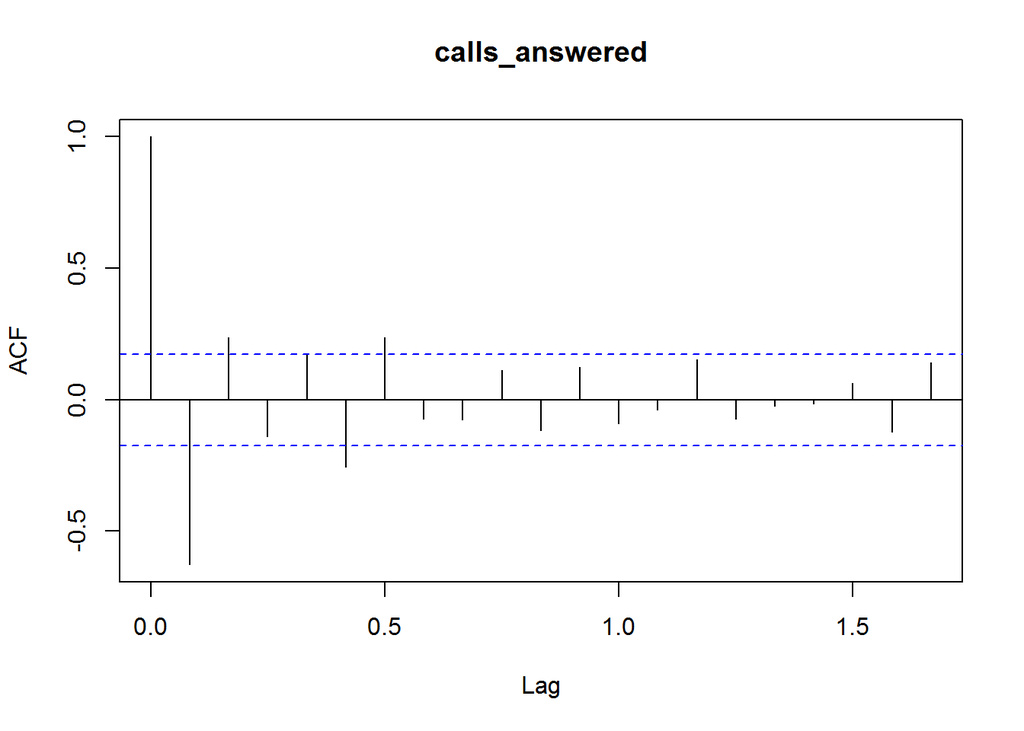

```r
acf(TimeSeriesDataDiff2, lag.max=20)
```

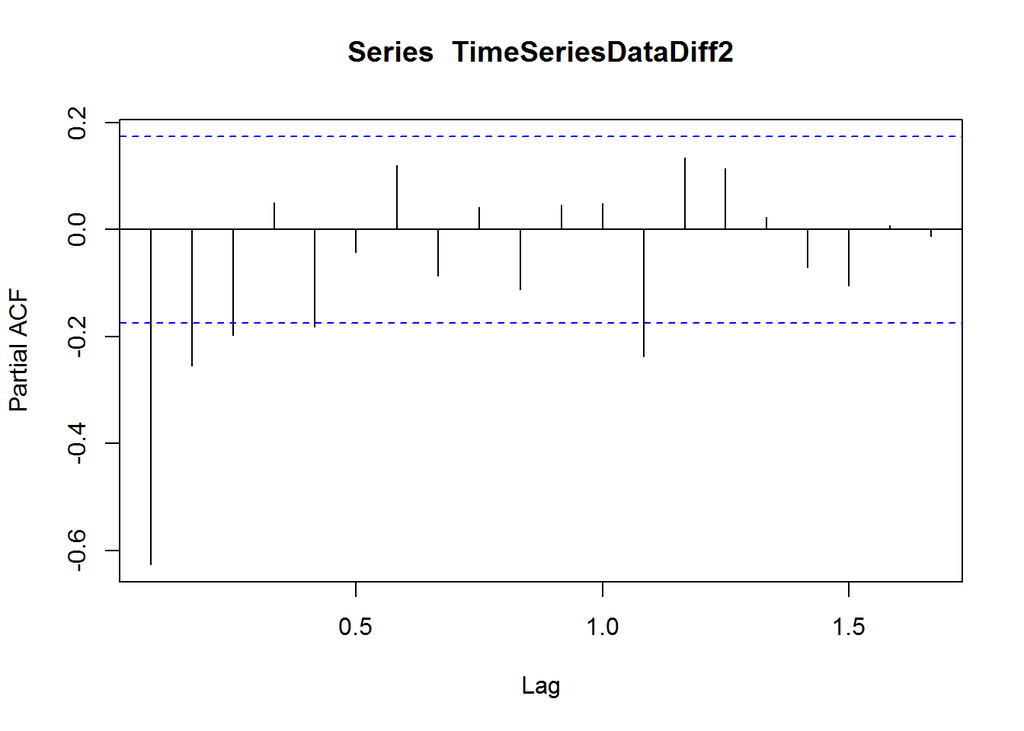

```r
pacf(TimeSeriesDataDiff2, lag.max=20)
```

We assume that the model with the fewest parameters is best. The ARMA(4,0) model has 4 parameters, the ARMA(0,1) model has 1 parameter, and the ARMA(p,q) model has at least 2 parameters. Therefore, the ARMA(0,1) model is taken as the best model.

```r
timeseriesarima <- arima(TimeSeriesData, order=c(0,2,1)) # fit an ARIMA(0,2,1) model
timeseriesarima
```

```
##
## Call:
## arima(x = TimeSeriesData, order = c(0, 2, 1))
##
## Coefficients:
##           ma1
##       -1.0000
## s.e.   0.0223
##
## sigma^2 estimated as 2.111e+09:  log likelihood = -1546,  aic = 3095.99
```

We can then use the ARIMA model to make forecasts for future values of the time series, using the “forecast.Arima()” function in the “forecast” R package.

```r
timeseriesarimaforecasts <- forecast:::forecast.Arima(timeseriesarima, h=36)
```

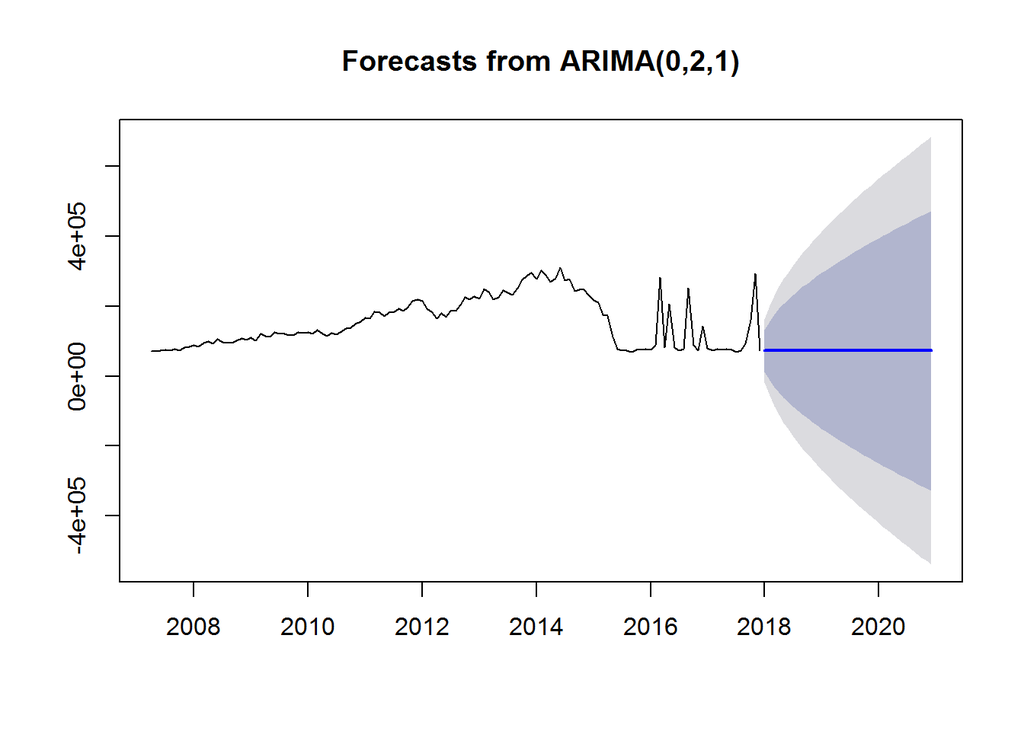

```r
plot(timeseriesarimaforecasts)
```

As before,we can investigate whether the predictive model can be improved upon by checking whether the in-sample forecast errors show non-zero autocorrelations at lags 1-20, by making a correlogram and carrying out the Ljung-Box test:

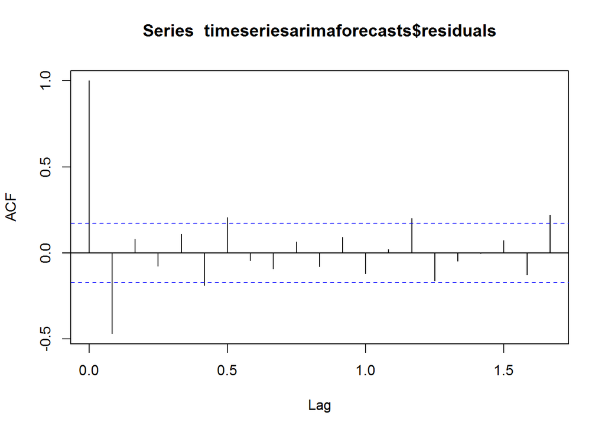

```r
acf(timeseriesarimaforecasts$residuals, lag.max=20,na.action = na.pass)
```

We also perform Ljung Box Test

```r
Box.test(timeseriesarimaforecasts$residuals, lag=20, type="Ljung-Box")
```

```
##
##  Box-Ljung test
##
## data:  timeseriesarimaforecasts$residuals
## X-squared = 70.192, df = 20, p-value = 1.695e-07
```

The correlogram shows that the autocorrelations for the in-sample forecast errors exceed the significance bounds for many of the lags 1-20. Furthermore, the p-value for Ljung-Box test is very low, indicating that there is evidence of non-zero autocorrelations at lags 1-20.

This indicates that the ARIMA model can also be improved upon.

Next, we move on to Python and try some other approaches using Deep Learning